# Homework 1

1/27/20

# Activity 1

```r
?mtcars

head(mtcars)
```

|  | mpg | cyl | disp | hp | drat | wt | qsec | vs | am | gear | carb |
| --- | --- | --- | --- | --- | --- | --- | --- | --- | --- | --- | --- |
| Mazda RX4 | 21.0 | 6 | 160 | 110 | 3.90 | 2.620 | 16.46 | 0 | 1 | 4 | 4 |
| Mazda RX4 Wag | 21.0 | 6 | 160 | 110 | 3.90 | 2.875 | 17.02 | 0 | 1 | 4 | 4 |
| Datsun 710 | 22.8 | 4 | 108 | 93 | 3.85 | 2.320 | 18.61 | 1 | 1 | 4 | 1 |
| Hornet 4 Drive | 21.4 | 6 | 258 | 110 | 3.08 | 3.215 | 19.44 | 1 | 0 | 3 | 1 |
| Hornet Sportabout | 18.7 | 8 | 360 | 175 | 3.15 | 3.440 | 17.02 | 0 | 0 | 3 | 2 |
| Valiant | 18.1 | 6 | 225 | 105 | 2.76 | 3.460 | 20.22 | 1 | 0 | 3 | 1 |

```r
summary(mtcars)
```

```
      mpg             cyl             disp             hp             drat             wt
 Min.   :10.40   Min.   :4.000   Min.   : 71.1   Min.   : 52.0   Min.   :2.760   Min.   :1.513
 1st Qu.:15.43   1st Qu.:4.000   1st Qu.:120.8   1st Qu.: 96.5   1st Qu.:3.080   1st Qu.:2.581
 Median :19.20   Median :6.000   Median :196.3   Median :123.0   Median :3.695   Median :3.325
 Mean   :20.09   Mean   :6.188   Mean   :230.7   Mean   :146.7   Mean   :3.597   Mean   :3.217
 3rd Qu.:22.80   3rd Qu.:8.000   3rd Qu.:326.0   3rd Qu.:180.0   3rd Qu.:3.920   3rd Qu.:3.610
 Max.   :33.90   Max.   :8.000   Max.   :472.0   Max.   :335.0   Max.   :4.930   Max.   :5.424
      qsec             vs               am              gear            carb
 Min.   :14.50   Min.   :0.0000   Min.   :0.0000   Min.   :3.000   Min.   :1.000
 1st Qu.:16.89   1st Qu.:0.0000   1st Qu.:0.0000   1st Qu.:3.000   1st Qu.:2.000
 Median :17.71   Median :0.0000   Median :0.0000   Median :4.000   Median :2.000
 Mean   :17.85   Mean   :0.4375   Mean   :0.4062   Mean   :3.688   Mean   :2.812
 3rd Qu.:18.90   3rd Qu.:1.0000   3rd Qu.:1.0000   3rd Qu.:4.000   3rd Qu.:4.000
 Max.   :22.90   Max.   :1.0000   Max.   :1.0000   Max.   :5.000   Max.   :8.000
```

1a) 335 1b) 3,325

# Activity 2

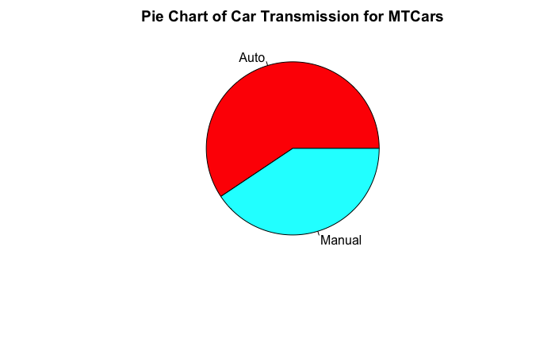

```r
ttype=table(mtcars$am) #To get the levels of the variable
ttype_lbls=c("Auto","Manual")
pie(ttype,labels=ttype_lbls,col=rainbow(length(ttype_lbls)),main="Pie Chart of Car Transmission for MTCars")
```

# Activity 3

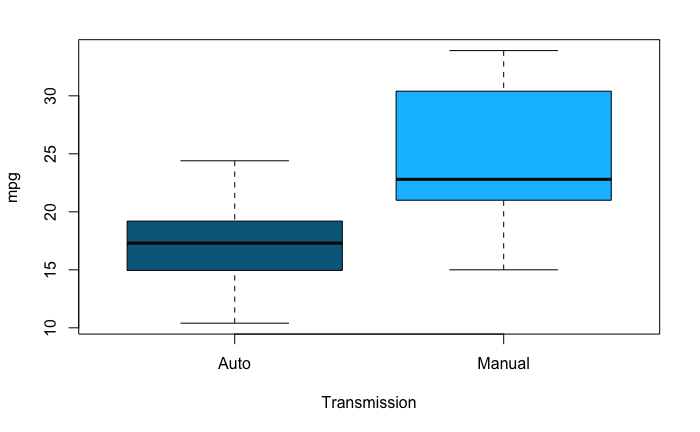

```r
boxplot(mpg~am,data=mtcars,xlab="Transmission",ylab="mpg",col=c("deepskyblue4","deepskyblue"),names=c("Auto","Manual"))
```

Based on the boxplot, I can infer that cars with manual transmissions generally have high a higher mpg than cars with automatic transmissions.

# Activity 4

```r
mean(mtcars$mpg)
```

```
[1] 20.09062
```

```r
sd(mtcars$mpg)
```

```
[1] 6.026948
```

# Activity 5

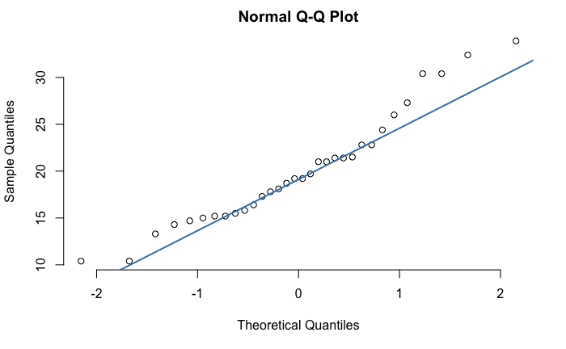

```r
qqnorm(mtcars$mpg, pch = 1, frame = FALSE)
qqline(mtcars$mpg, col = "steelblue", lwd = 2)
```

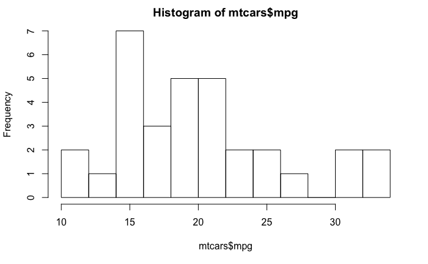

```r
hist(mtcars$mpg,br=10)
```

A normal QQ-plot is a scatterplot of two quantiles against each other that forms a roughly straight line. In this case, it is difficult for us to tell if the data comes from a population with a normal distribution because the data does not really form a straight line, meaning that it most likely isn’t normal.

# Activity 6

6a. If X ∼ N(5,2), then find P(X ≤ 4) [3 marks]

6b. If X ∼ N(5,2), then find P(X > 6) [3 marks]

6c. If X ∼ N(10,1), then find P(X < 9) [3 marks]

7a. If X ∼ N(5,2), then find the value a such that P(X < a) = 0.025 [3 marks]

7b. If X ∼ N(5,2), then find the value a such that P(X > a) = 0.025 [3 marks]

7c. If X ∼ N(10,1), then find the value a such that P(X > a) = 0.55 [3 marks]

```r
pnorm(4, mean = 5, sd = sqrt(2), lower.tail = TRUE, log.p = FALSE)
```

```
[1] 0.2397501
```

```r
pnorm(6, mean = 5, sd = sqrt(2), lower.tail = FALSE, log.p = FALSE)
```

```
[1] 0.2397501
```

```r
pnorm(9, mean = 10, sd = 1, lower.tail = TRUE, log.p = FALSE)
```

```
[1] 0.1586553
```

```r
qnorm(.025, mean = 5, sd = sqrt(2), lower.tail = TRUE, log.p = FALSE)
```

```
[1] 2.228192
```

```r
qnorm(.025, mean = 5, sd = sqrt(2), lower.tail = FALSE, log.p = FALSE)
```

```
[1] 7.771808
```

```r
qnorm(.55, mean = 10, sd = 1, lower.tail = FALSE, log.p = FALSE)
```

```
[1] 9.874339
```

Question 8. Records maintained by the your admin office indicate that amount of time elapsed between the submission of travel receipts and the final reimbursement of funds has approximately a normal distribution with a mean of 39 days and a standard deviation of 6 days.

If you submitted your travel claim 55 days ago, what is the probability that it should have been returned by now? What might you conclude? You can do this either by hand or in R. [6 marks]

```r
pnorm(55, mean = 39, sd = 6, lower.tail = TRUE, log.p = FALSE)
```

```
[1] 0.9961696
```